(aaresade)=

# Aare

English

**Unten:** Karte des Erhebungsgebiets März 2020 - Mai 2021. Durchmesser der Punktsymbole = das mittlere Erhebungsergebnis in gefundene Abfallobjekte pro 100 Meter (p/100m).

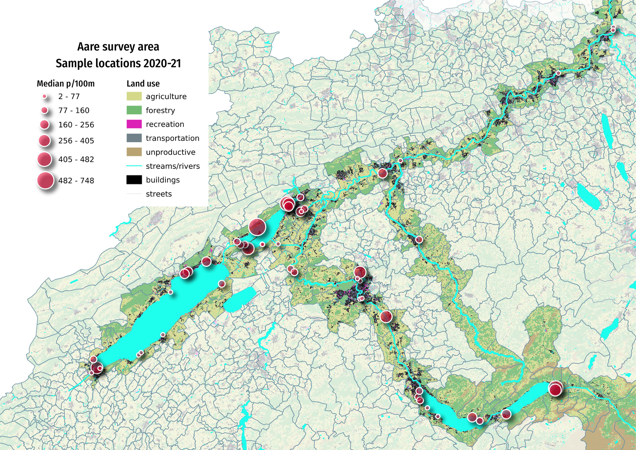

## Erhebungsorte und Landnutzungsmerkmale

Für den Zeitraum zwischen 03.2020 und 05.2021, wurden im Rahmen von 140 Datenerhebungen insgesamt 13'847 Objekte entfernt und identifiziert. Die Ergebnisse des Aare-Erhebungsgebiets umfassen 51 Orte, 35 Gemeinden und eine Gesamtbevölkerung von etwa 493'799 Einwohnern.

*Seen:*

> Bielersee, Brienzersee, Neuenburgersee, Thunersee

*Flüsse:*

> Aare, Aare|Nidau-Büren-Kanal, Emme, La Thièle, Schüss

*Gemeinden:*

> Aarau, Beatenberg, Bern, Biel/Bienne, Boudry, Brienz (BE), Brugg, Brügg, Burgdorf, Bönigen, Cheyres-Châbles, Cudrefin, Erlach, Estavayer, Gals, Gebenstorf, Grandson, Hauterive (NE), Kallnach, Köniz, Le Landeron, Ligerz, Luterbach, Lüscherz, Neuchâtel, Nidau, Port, Rubigen, Solothurn, Spiez, Thun, Unterseen, Vinelz, Walperswil, Yverdon-les-Bains

### Landnutzungsprofil der Erhebungsorte

Die Landnutzung wird als Prozentsatz der Gesamtfläche angegeben, die jeder Landnutzungskategorie innerhalb eines Radius von 1'500 m um den Erhebungsort zugeordnet wird.

Strassen werden als Gesamtzahl der Strassenkilometer im Umkreis von 1'500 m angegeben. Flussmündung ist ebenfalls eine ordinale Rangfolge der Anzahl der Flüsse/Kanäle, die einen See innerhalb von 1'500 m um den Erhebungsort herum durchqueren.

Das Verhältnis der Anzahl der Erhebungen bei unterschiedlichen Landnutzungsprofilen gibt einen Hinweis auf die ökologischen und wirtschaftlichen Rahmenbedingungen der Untersuchungsstandorte.

Für weitere Informationen *Landnutzungsprofil*.

**Unten:** Landnutzungsprofil der Erhebungsorte. Verteilung der Erhebungen in Bezug auf die Landnutzung.

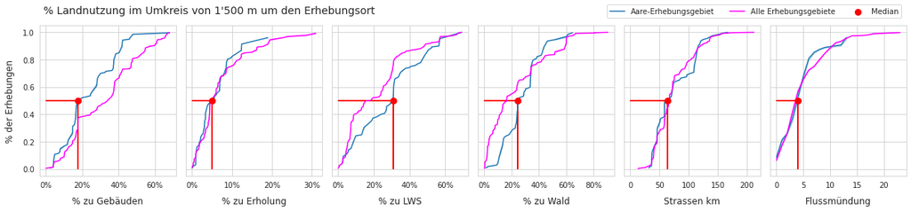

### Kumulative Gesamtmengen nach Gewässer

**Unten:** Die kumulierten Gewichte und Merkmale für das Aare-Erhebungsgebietund dessen Gewässer.

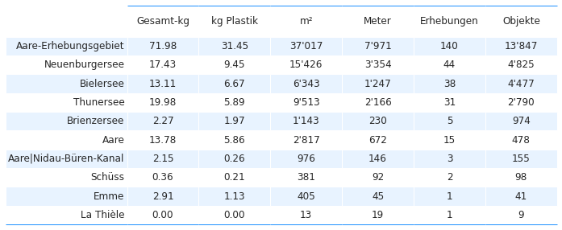

### Verteilung der Ergebnisse der Datenerhebungen

**Links:** Aare-Erhebungsgebiet, 03.2020 bis 05.2021, n=140. Werte grösser als 1'766 p/100m werden nicht gezeigt. **Rechts:** Aare-Erhebungsgebiet empirische kumulative Verteilung der Datenerhebungen.

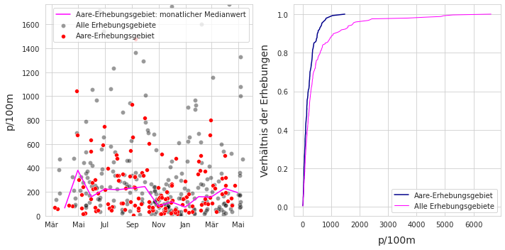

### Zusammengefasste Daten und Materialarten

**Links:** Zusammenfassung der Daten aller Erhebungen im Aare-Erhebungsgebiet. **Rechts:** Gefundene Materialarten im Aare-Erhebungsgebiet und Prozentsatz deren Gesamtmenge.

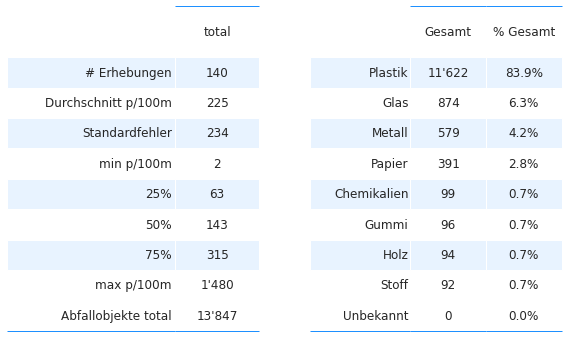

## Die am häufigsten gefundenen Objekte

Die am häufigsten gefundenen Objekte sind die zehn mengenmässig am meisten vorkommenden Objekte UND/ODER Objekte, die in mindestens 50% aller Datenerhebungen identifiziert wurden (fail-rate).

**Unten:** Häufigste Objekte im Aare-Erhebungsgebiet: fail-rate >/= 50% und/oder Top Ten nach Anzahl. Zusammengenommen machen die häufigsten Objekte 67% aller gefundenen Objekte aus. Anmerkung: p/100m = Medianwert der Erhebung.

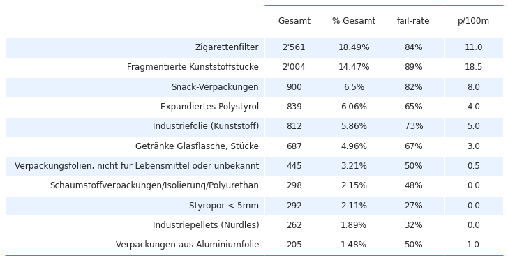

### Die am häufigsten gefundenen Objekte nach Gewässer

**Unten:** häufigste Objekte im Aare-Erhebungsgebiet: Median p/100m.

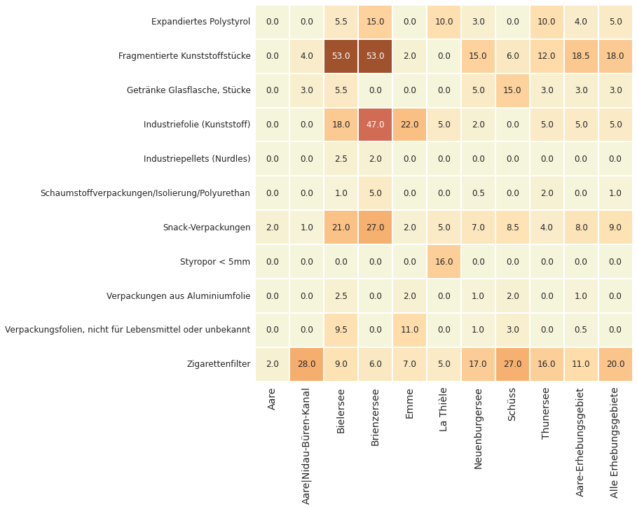

### Die am häufigsten gefundenen Objekte im monatlichen Durchschnitt

**Unten:** Aare-Erhebungsgebiet, monatliche Durchschnittsergebnisse p/100m.

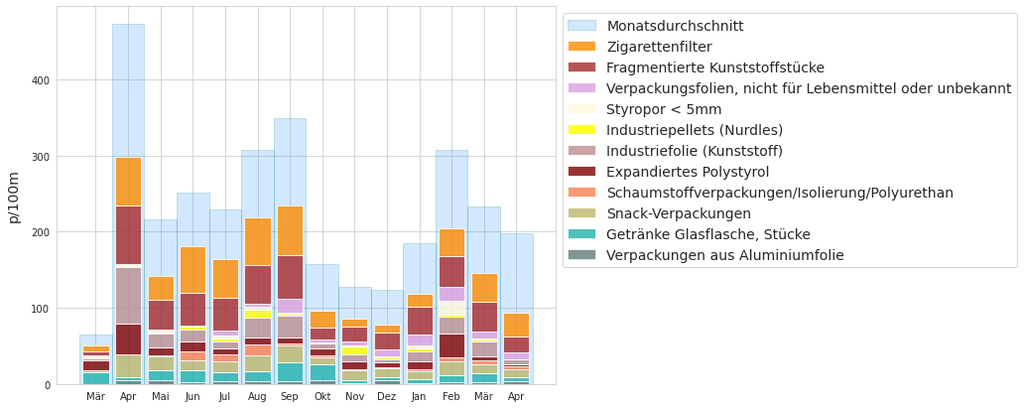

## Ergebnisse der Datenerhebungen und Landnutzung

Der Flächennutzungsmix ist eine einzigartige Darstellung der Art und des Umfangs der wirtschaftlichen Aktivität und der Umweltbedingungen rund um den Erhebungsort. Die Schlüsselindikatoren aus den Ergebnissen der Datenerhebungen werden mit den Flächennutzungsraten für einen Radius von 1500 m um den Erhebungsort verglichen.

Eine Assoziation ist eine Beziehung zwischen den Ergebnissen der Datenerhebungen und dem Landnutzungsprofil, die nicht auf Zufall beruht. Das Ausmass der Beziehung ist weder definiert noch linear.

Die Rangkorrelation ist ein nicht-parametrischer Test, um festzustellen, ob ein statistisch signifikanter Zusammenhang zwischen der Landnutzung und den bei einer Abfallobjekte-Erhebung identifizierten Objekten besteht.

Die verwendete Methode ist der Spearman’s rho oder Spearmans geordneter Korrelationskoeffizient. Die Testergebnisse werden bei p<0,05 für alle gültigen Erhebungen an Seen im Untersuchungsgebiet ausgewertet.

1. Rot/Rosa ist eine positive Assoziation
2. Gelb ist eine negative Assoziation
3. Weiss ist keine statistische Grundlage für die Annahme eines Zusammenhangs, p>0,05

*Unten: Ausgewertete Korrelation der am häufigsten gefundenen Objekte in Bezug auf das Landnutzungsprofil im Aare-Erhebungsgebiet. Für alle gültigen Erhebungen an Seen n=118.*

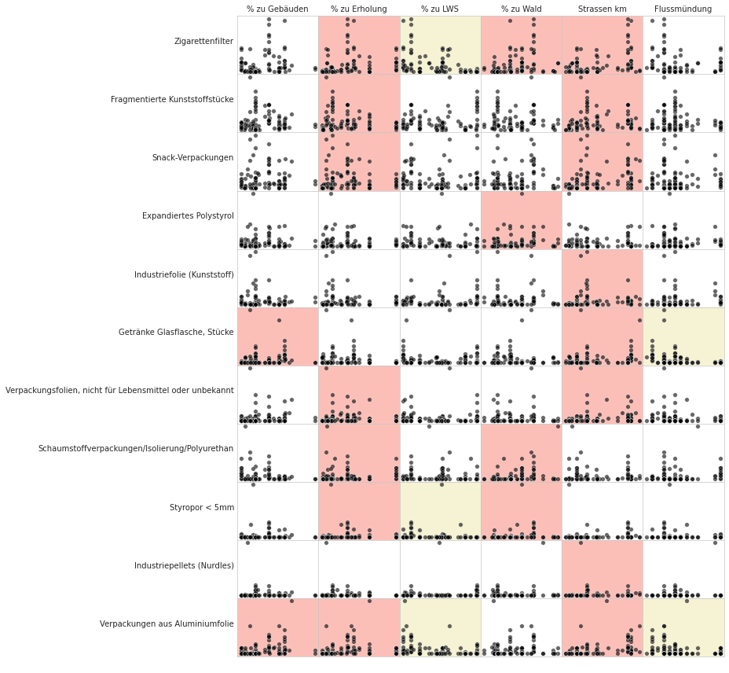

*Legende: wenn p >0,05 = weiss, wenn p < 0,05 und rho > 0 = rot, wenn p < 0,05 und rho < 0 = gelb*

## Verwendungszweck der gefundenen Objekte

Die Nutzungsart basiert auf der Verwendung des Objekts, bevor es weggeworfen wurde, oder auf der Artikelbeschreibung, wenn die ursprüngliche Verwendung unbestimmt ist. Identifizierte Objekte werden einer der 260 vordefinierten Kategorien zugeordnet. Die Kategorien werden je nach Verwendung oder Artikelbeschreibung gruppiert.

- **Abwasser:** Gegenstände, die aus Kläranlagen freigesetzt werden, einschliesslich Gegenstände, die wahrscheinlich über die Toilette entsorgt werden
- **Mikroplastik (< 5 mm):** fragmentierte Kunststoffe und Kunststoffharze aus der Vorproduktion
- **Infrastruktur:** Artikel im Zusammenhang mit dem Bau und der Instandhaltung von Gebäuden, Strassen und der Wasser-/Stromversorgung
- **Essen und Trinken:** alle Materialien, die mit dem Konsum von Essen und Trinken in Zusammenhang stehen
- **Landwirtschaft:** z. B. für Mulch und Reihenabdeckungen, Gewächshäuser, Bodenbegasung, Ballenverpackungen. Einschliesslich Hartkunststoffe für landwirtschaftliche Zäune, Blumentöpfe usw.
- **Tabak:** hauptsächlich Zigarettenfilter, einschliesslich aller mit dem Rauchen verbundenen Materialien
- **Freizeit und Erholung:** Objekte, die mit Sport und Freizeit zu tun haben, z. B. Angeln, Jagen, Wandern usw.
- **Verpackungen ausser Lebensmittel und Getränke:** Verpackungsmaterial, das nicht lebensmittel-, getränke- oder tabakbezogen ist
- **Plastikfragmente:** Plastikteile unbestimmter Herkunft oder Verwendung
- **Persönliche Gegenstände:** Accessoires, Hygieneartikel und Kleidung

Im Anhang finden Sie die vollständige Liste der identifizierten Objekte, einschliesslich Beschreibungen und Gruppenklassifizierung. Der Abschnitt Code-Gruppen beschreibt jede Codegruppe im Detail und bietet eine umfassende Liste aller Objekte in einer Gruppe.

**Unten:** Verwendungszweck oder Beschreibung der identifizierten Objekte in % der Gesamtzahl nach Gewässer im Aare-Erhebungsgebiet. Fragmentierte Objekte, die nicht eindeutig identifiziert werden können, werden weiterhin nach ihrer Grösse klassifiziert.

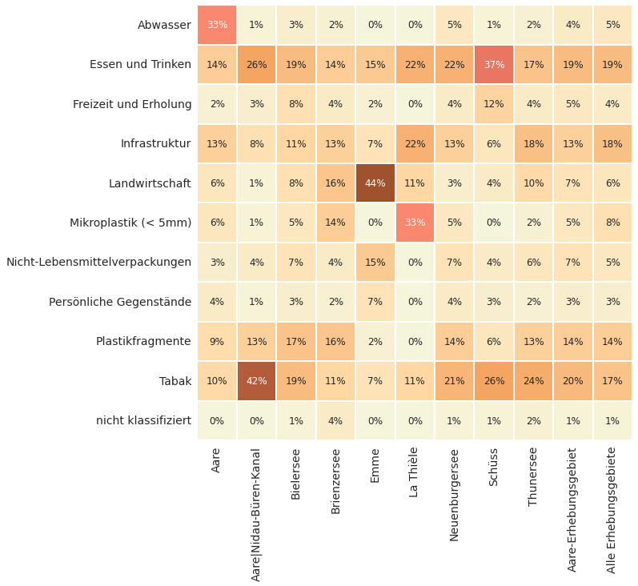

**Unten:** Verwendungszweck der gefundenen Objekte Median p/100m im Aare-Erhebungsgebiet. Fragmentierte Objekte, die nicht eindeutig identifiziert werden können, werden weiterhin nach ihrer Grösse klassifiziert.

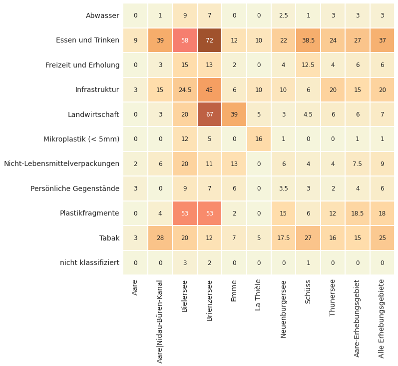

## Flüsse

**Links:** Aare-Erhebungsgebiet Flüsse, 03.2020 bis 05.2021, n=22. Werte grösser als 1'766 p/100m werden nicht gezeigt. **Rechts:** Zusammenfassende der Daten.

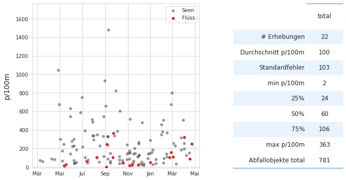

### Die an Flüssen am häufigsten gefundene Objekte

*Häufigste Objekte p/100m an Flüssen im Aare-Erhebungsgebiet: Medianwert der Erhebung.*

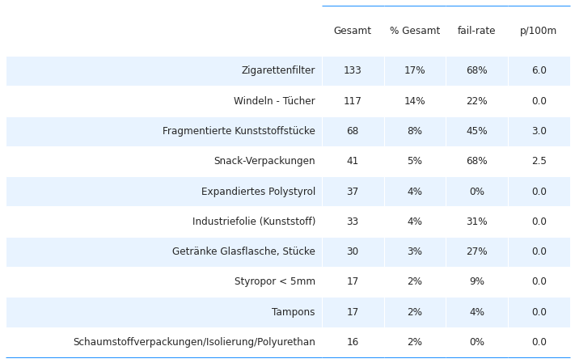

## Anhang

### Schaumstoffe und Kunststoffe nach Grösse

Die folgende Tabelle enthält die Komponenten "Gfoam" und "Gfrags", die für die Analyse gruppiert wurden. Objekte, die als Schaumstoffe gekennzeichnet sind, werden als Gfoam gruppiert und umfassen alle geschäumten Polystyrol-Kunststoffe > 0,5 cm. Kunststoffteile und Objekte aus kombinierten Kunststoff- und Schaumstoffmaterialien > 0,5 cm werden für die Analyse als Gfrags gruppiert.

**Unten:** Fragmentierte und geschäumte Kunststoffe nach Grösse im Aare-Erhebungsgebiet, Median p/100m, Anzahl der gefundenen Stücke und Prozent der Gesamtmenge.

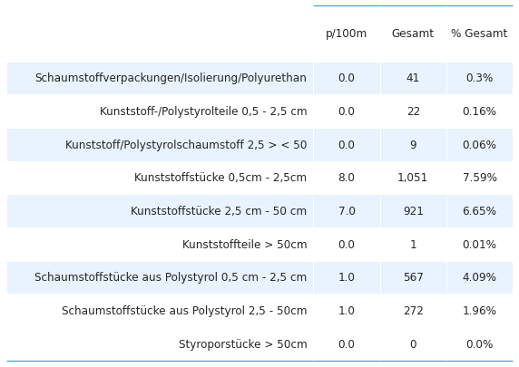

### Die Erhebungsorte

| Standort | latitude | longitude | Stadt |
| --- | --- | --- | --- |
| aare-port | 47.116170 | 7.269550 | Port |
| schutzenmatte | 47.057666 | 7.634001 | Burgdorf |
| la-petite-plage | 46.785054 | 6.656877 | Yverdon-les-Bains |
| weissenau-neuhaus | 46.676583 | 7.817528 | Unterseen |
| evole-plage | 46.989477 | 6.923920 | Neuchâtel |
| oberi-chlihochstetten | 46.896025 | 7.532114 | Rubigen |
| plage-de-serriere | 46.984850 | 6.913450 | Neuchâtel |
| mullermatte | 47.133339 | 7.227907 | Biel/Bienne |
| bielersee_vinelz_fankhausers | 47.038398 | 7.108311 | Vinelz |
| erlach-camping-strand | 47.047159 | 7.097854 | Erlach |
| gummligrabbe | 46.989290 | 7.250730 | Kallnach |
| mannewil | 46.996382 | 7.239024 | Kallnach |
| schusspark-strand | 47.146500 | 7.268620 | Biel/Bienne |
| plage-de-cheyres | 46.818689 | 6.782256 | Cheyres-Châbles |
| thun-strandbad | 46.739939 | 7.633520 | Thun |
| oben-am-see | 46.744451 | 8.049921 | Brienz (BE) |
| thunersee_spiez_meierd_1 | 46.704437 | 7.657882 | Spiez |
| spackmatt | 47.223749 | 7.576711 | Luterbach |
| luscherz-plage | 47.047955 | 7.151242 | Lüscherz |
| strandboden-biel | 47.132510 | 7.233142 | Biel/Bienne |
| signalpain | 46.786200 | 6.647360 | Yverdon-les-Bains |
| pointe-dareuse | 46.946190 | 6.870970 | Boudry |
| nidau-strand | 47.127196 | 7.232613 | Nidau |
| camp-des-peches | 47.052812 | 7.074053 | Le Landeron |
| delta-park | 46.720078 | 7.635304 | Spiez |
| pecos-plage | 46.803590 | 6.636650 | Grandson |
| beich | 47.048495 | 7.200528 | Walperswil |
| aare_suhrespitz_badert | 47.405669 | 8.066018 | Aarau |
| sundbach-strand | 46.684386 | 7.794768 | Beatenberg |
| wycheley | 46.740370 | 8.048640 | Brienz (BE) |
| aare_koniz_hoppej | 46.934588 | 7.458170 | Köniz |
| camping-gwatt-strand | 46.727140 | 7.629620 | Thun |
| bern-tiergarten | 46.933157 | 7.452004 | Bern |
| la-thiele_le-mujon_confluence | 46.775340 | 6.630900 | Yverdon-les-Bains |
| nouvelle-plage | 46.856646 | 6.848428 | Estavayer |
| augustmutzenbergstrandweg | 46.686640 | 7.689760 | Spiez |
| aare_bern_gerberm | 46.989363 | 7.452098 | Bern |
| brugg-be-buren-bsg-standort | 47.122220 | 7.281410 | Brügg |
| ruisseau-de-la-croix-plage | 46.813920 | 6.774700 | Cheyres-Châbles |
| ligerz-strand | 47.083979 | 7.135894 | Ligerz |
| hafeli | 46.690283 | 7.898592 | Bönigen |
| aare-solothurn-lido-strand | 47.196949 | 7.521643 | Solothurn |
| bern-fahrstrasse | 46.975866 | 7.444210 | Bern |
| gals-reserve | 47.046272 | 7.085007 | Gals |
| hauterive-petite-plage | 47.010797 | 6.980304 | Hauterive (NE) |
| aare-limmatspitz | 47.501060 | 8.237371 | Gebenstorf |
| aare_brugg_buchie | 47.494855 | 8.236558 | Brugg |
| luscherz-two | 47.047519 | 7.152829 | Lüscherz |
| impromptu_cudrefin | 46.964496 | 7.027936 | Cudrefin |
| aare_post | 47.116665 | 7.271953 | Port |
| aare_bern_scheurerk | 46.970967 | 7.452586 | Bern |

### Inventar der Objekte

| code | Objekte | Gruppenname | Menge | % Gesamt | Fail-Pass |
| --- | --- | --- | --- | --- | --- |
| G27 | Zigarettenfilter | Tabak | 2561 | 18.49 | 84 |
| Gfrags | Fragmentierte Kunststoffstücke | Plastikfragmente | 2004 | 14.47 | 89 |
| G30 | Snack-Verpackungen | Essen und Trinken | 900 | 6.50 | 82 |
| Gfoam | Expandiertes Polystyrol | Infrastruktur | 839 | 6.06 | 65 |
| G67 | Industriefolie (Kunststoff) | Landwirtschaft | 812 | 5.86 | 73 |
| G200 | Getränke Glasflasche, Stücke | Essen und Trinken | 687 | 4.96 | 67 |
| G941 | Verpackungsfolien, nicht für Lebensmittel oder... | Nicht-Lebensmittelverpackungen | 445 | 3.21 | 50 |
| G74 | Schaumstoffverpackungen/Isolierung/Polyurethan | Infrastruktur | 298 | 2.15 | 48 |
| G117 | Styropor < 5mm | Mikroplastik (< 5mm) | 292 | 2.11 | 27 |
| G112 | Industriepellets (Nurdles) | Mikroplastik (< 5mm) | 262 | 1.89 | 32 |
| G98 | Windeln - Tücher | Abwasser | 258 | 1.86 | 28 |
| G89 | Kunststoff-Bauabfälle | Infrastruktur | 219 | 1.58 | 49 |
| G177 | Verpackungen aus Aluminiumfolie | Essen und Trinken | 205 | 1.48 | 50 |
| G95 | Wattestäbchen | Abwasser | 201 | 1.45 | 49 |
| G25 | Tabak; Kunststoffverpackungen, Behälter | Tabak | 159 | 1.15 | 43 |
| G904 | Feuerwerkskörper; Raketenkappen | Freizeit und Erholung | 155 | 1.12 | 41 |
| G156 | Papierfragmente | Nicht-Lebensmittelverpackungen | 150 | 1.08 | 28 |
| G178 | Flaschenverschlüsse aus Metall | Essen und Trinken | 123 | 0.89 | 40 |
| G106 | Kunststofffragmente eckig <5mm | Mikroplastik (< 5mm) | 104 | 0.75 | 27 |
| G940 | Schaumstoff EVA (flexibler Kunststoff) | Freizeit und Erholung | 102 | 0.74 | 11 |
| G21 | Getränke-Deckel, Getränkeverschluss | Essen und Trinken | 98 | 0.71 | 31 |
| G213 | Paraffinwachs | Freizeit und Erholung | 98 | 0.71 | 18 |
| G50 | Schnur < 1cm | Freizeit und Erholung | 96 | 0.69 | 36 |
| G23 | unidentifizierte Deckel | Nicht-Lebensmittelverpackungen | 93 | 0.67 | 30 |
| G33 | Einwegartikel; Tassen/Becher & Deckel | Essen und Trinken | 87 | 0.63 | 35 |
| G922 | Etiketten, Strichcodes | Nicht-Lebensmittelverpackungen | 87 | 0.63 | 32 |
| G35 | Strohhalme und Rührstäbchen | Essen und Trinken | 82 | 0.59 | 35 |
| G186 | Industrieschrott | Infrastruktur | 82 | 0.59 | 20 |
| G24 | Ringe von Plastikflaschen/Behältern | Essen und Trinken | 80 | 0.58 | 28 |
| G10 | Lebensmittelbehälter zum einmaligen Gebrauch a... | Essen und Trinken | 74 | 0.53 | 28 |

[output cut: 149 more lines]